# Quiz 3

## Quiz 3

### Question 1

Load the cell segmentation data from the AppliedPredictiveModeling package using the commands:

```r
library(AppliedPredictiveModeling)
data(segmentationOriginal)
suppressMessages(library(caret))
```

1. Subset the data to a training set and testing set based on the Case variable in the data set.
2. Set the seed to 125 and fit a CART model with the rpart method using all predictor variables and default caret settings.
3. In the final model what would be the final model prediction for cases with the following variable values:
   1. TotalIntench2 = 23,000; FiberWidthCh1 = 10; PerimStatusCh1 = 2
   2. TotalIntench2 = 50,000; FiberWidthCh1 = 10; VarIntenCh4 = 100
   3. TotalIntench2 = 57,000; FiberWidthCh1 = 8; VarIntenCh4 = 100
   4. FiberWidthCh1 = 8; VarIntenCh4 = 100; PerimStatusCh1 = 2

### Solution

```r
# Create a data partition and allocate training and testing datasets
selectTrain <- createDataPartition(y = segmentationOriginal$Case,
                                   p = 0.6,
                                   list = FALSE)
train <- segmentationOriginal[selectTrain, ]
test <- segmentationOriginal[-selectTrain, ]

# Set the seed and fit a model
set.seed(125)
model <- train(Class ~ ., method = "rpart", data = train)
model$finalModel
```

```
## n= 1212
##
## node), split, n, loss, yval, (yprob)
##       * denotes terminal node
##
## 1) root 1212 437 PS (0.63943894 0.36056106)
##   2) TotalIntenCh2< 47713 573  46 PS (0.91972077 0.08027923) *
##   3) TotalIntenCh2>=47713 639 248 WS (0.38810642 0.61189358)
##     6) ConvexHullAreaRatioCh1>=1.106555 276 114 PS (0.58695652 0.41304348) *
##     7) ConvexHullAreaRatioCh1< 1.106555 363  86 WS (0.23691460 0.76308540) *
```

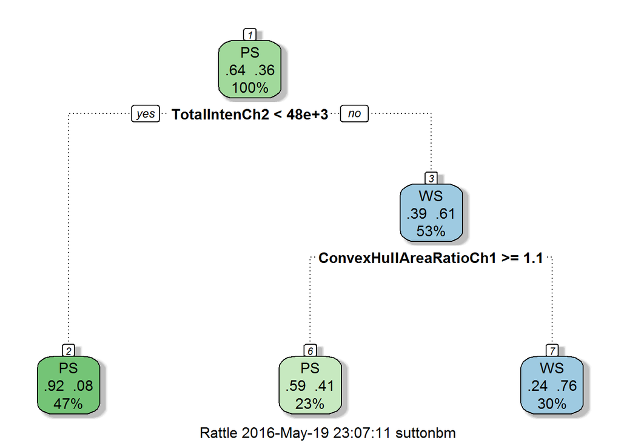

```r
suppressMessages(library(rattle))
library(rpart.plot)
fancyRpartPlot(model$finalModel)
```

### Question 2

If K is small in a K-fold cross validation is the bias in the estimate of out-of-sample (test set) accuracy smaller or bigger? If K is small is the variance in the estimate of out-of-sample (test set) accuracy smaller or bigger. Is K large or small in leave one out cross validation?

### Solution

The bias is larger and the variance is smaller. Under leave-one-out, cross validation K is equal to the sample size.

### Question 3

Load the olive oil data using the commands:

```r
library(pgmm)
data(olive)
olive = olive[, -1]
```

These data contain information on 572 different Italian olive oils from multiple regions in Italy. Fit a classification tree where Area is the outcome variable. Then predict the value of area for the following data frame using the tree command with all defaults:

```r
newdata = as.data.frame(t(colMeans(olive)))
```

What is the resulting prediction? Is the resulting prediction strange? Why or why not?

### Solution

```r
modelOlive <- train(Area ~ ., method = "rpart", data = olive)
predict(modelOlive, newdata=newdata)
```

```
##        1
## 2.783282
```

The predicted value is strange because `Area` should be a qualitative variable. However, the tree is reporting the average value of Area as a numerical value.

### Question 4

Load the South Africa Heart Disease Data and create training and test sets with the following code:

```r
library(ElemStatLearn)
data(SAheart)
set.seed(8484)
train = sample(1:dim(SAheart)[1], size = dim(SAheart)[1] / 2, replace = F)
trainSA = SAheart[train, ]
testSA = SAheart[-train, ]
```

Then set the seed to 13234 and fit a logistic regression model (method = “glm”, be sure to specify family = “binomial”) with Coronary Heart Disease (chd) as the outcome and age at onset, current alcohol consumption, obesity levels, cumulative tabacco, type-A behavior, and low density lipoprotein cholesterol as predictors. Calculate the misclassification rate for your model using this function and a prediction on the “response” scale:

```r
misClass = function(values, prediction){sum(((prediction > 0.5) * 1) != values) / length(values)}
```

What is the misclassification rate on the training set? What is the misclassification rate on the test set?

### Solution

```r
set.seed(13234)
model <- train(chd ~ age + alcohol + obesity + tobacco + typea + ldl,
               data = trainSA,
               method = "glm",
               family = "binomial")
misClass(trainSA$chd, predict(model, newdata=trainSA))
```

```
## [1] 0.2727273
```

### Question 5

Load the vowel.train and vowel.test data sets:

```r
library(ElemStatLearn)
data(vowel.train)
data(vowel.test)
```

Set the variable y to be a factor variable in both the training and test set. Then set the seed to 33833. Fit a random forest predictor relating the factor variable y to the remaining variables. Read about variable importance in random forests [here](http://www.stat.berkeley.edu/~breiman/RandomForests/cc_home.htm#ooberr). The caret package uses by defualt the Gini importance. Calculate the variable importance using the varImp function in the caret package. What is the order of variable importance?

### Solution

```r
vowel.train$y <- as.factor(vowel.train$y)
vowel.test$y <- as.factor(vowel.test$y)
set.seed(33833)
library(randomForest)
model <- randomForest(y ~ ., data = vowel.train)
order(varImp(model), decreasing = TRUE)
```

```
##  [1]  2  1  5  6  8  4  9  3  7 10
```